# Applied Computational Methods for Social Sciences

## geom_col

### fill(discrete)

Suppose we collected a small survey and just recorded the education level of each respondent. We want to visualize how many respondents fall into each category.

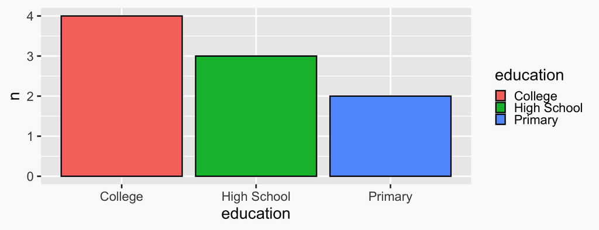

```r
# fill = education, color = black border
ggplot(eg3b, aes(x = education, y = n, fill = education)) +
  geom_col(color = "black", linewidth = 1)
```

# Line Aesthetics

## geom_line

### Aesthetics

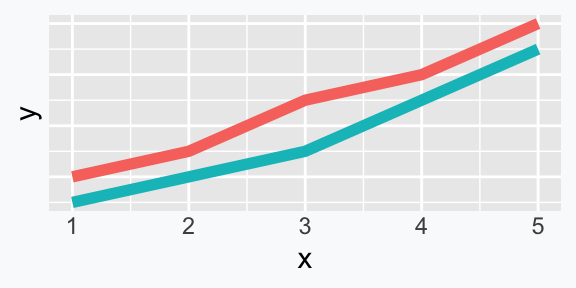

`color`(discrete)

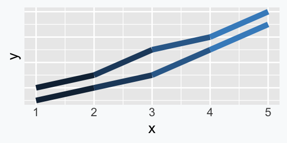

`color`(continuous)

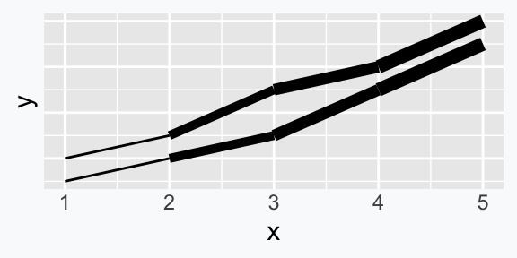

`size` - deprecated

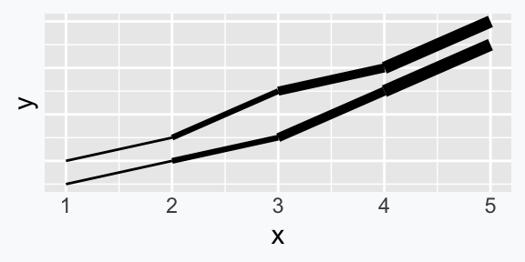

`linewidth`(discrete + continuous)

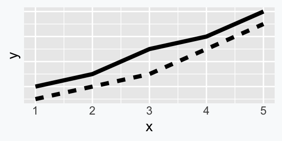

`linetype`(discrete)

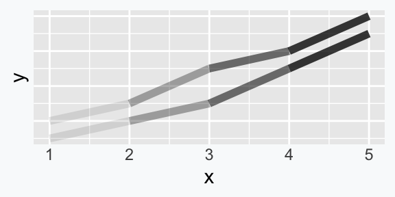

`alpha`(discrete+continuous)

## geom_line

### Aesthetics

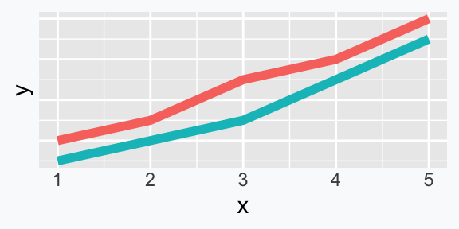

`color`(discrete)

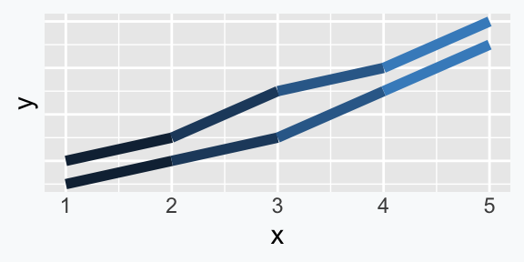

`color`(continuous)

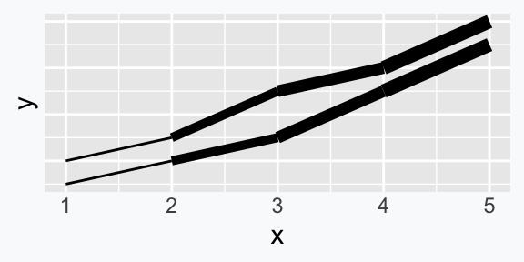

`size` - deprecated

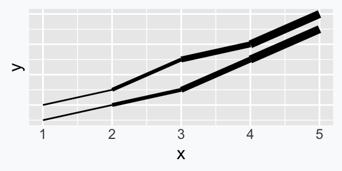

`linewidth`(discrete + continuous)

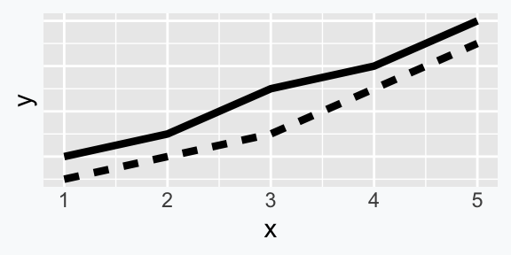

`linetype`(discrete)

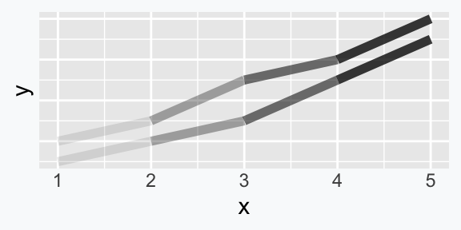

`alpha`(discrete+continuous)

| Aesthetic | Use for |
| --- | --- |
| `color` (discrete) | Distinguish groups with different line colors |
| `color` (continuous) | Show gradient along x or y values; possible but unusual (rare for lines) |
| `size` | Deprecated; replaced by `linewidth` |
| `linewidth` (discrete + continuous) | Vary line thickness to emphasize magnitude (sometimes used) or weight (rare for lines) |
| `linetype` (discrete) | Differentiate groups with solid/dashed/dotted styles |
| `alpha` (discrete + continuous) | Control transparency to reduce clutter when many lines overlap (rare for lines) |

## geom_line

### Simple Geom

Suppose we have data on average voter turnout (%) in national elections over several years. We want to see the trend in participation.

```r
# Toy dataset
eg4 <- data.frame(
  year = c(2000, 2004, 2008, 2012, 2016, 2020),
  turnout = c(55, 58, 62, 60, 59, 65)
)
```

| year | turnout |
| --- | --- |
| 2000 | 55 |
| 2004 | 58 |
| 2008 | 62 |
| 2012 | 60 |
| 2016 | 59 |
| 2020 | 65 |

## geom_line

### Simple Geom

Suppose we have data on average voter turnout (%) in national elections over several years. We want to see the trend in participation.

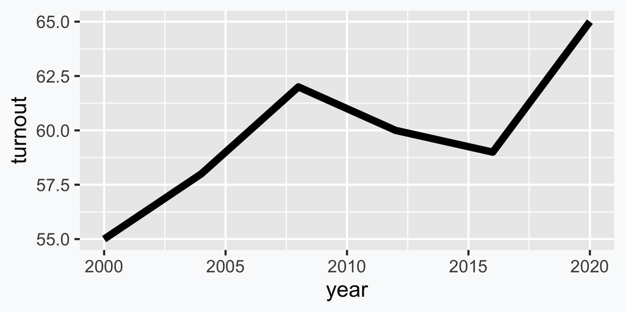

```r
ggplot(eg4, aes(x = year, y = turnout)) +
  geom_line()
```

## geom_line

### color(discrete)

Suppose we have data on average voter turnout (%) in national elections over several years for the US and the UK. We want to see the trend in participation.

```r
# Toy dataset with US and UK
eg5 <- data.frame(
  year = rep(c(2000, 2004, 2008, 2012, 2016, 2020), times = 2),
  turnout = c(
    # US presidential elections
    54, 60, 62, 58, 56, 65,
    # UK general elections (closest years aligned to US election years for teaching)
    59, 61, 65, 66, 68, 67
  ),
  country = rep(c("United States", "United Kingdom"), each = 6)
)
```

## geom_line

### color(discrete)

Suppose we have data on average voter turnout (%) in national elections over several years for the US and the UK. We want to see the trend in participation.

| year | turnout | country |
| --- | --- | --- |
| 2000 | 54 | United States |
| 2004 | 60 | United States |
| 2008 | 62 | United States |
| 2012 | 58 | United States |
| 2016 | 56 | United States |
| 2020 | 65 | United States |
| 2000 | 59 | United Kingdom |
| 2004 | 61 | United Kingdom |

## geom_line

### color(discrete)

Suppose we have data on average voter turnout (%) in national elections over several years for the US and the UK. We want to see the trend in participation.

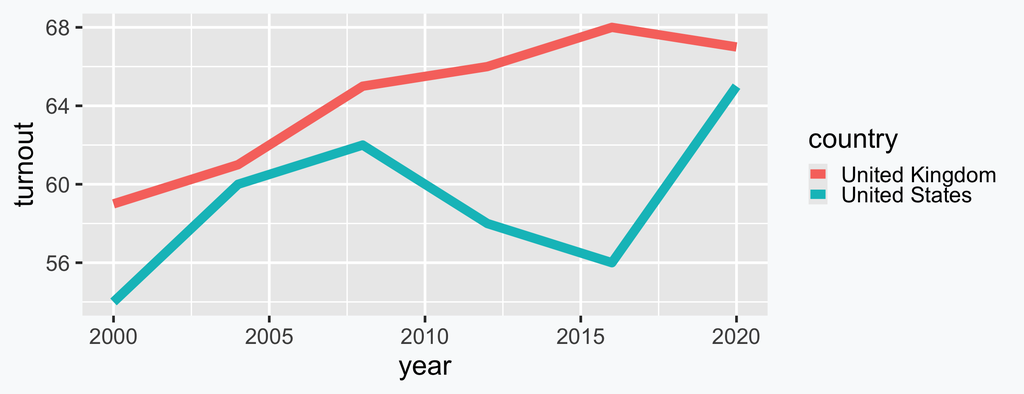

```r
ggplot(eg5, aes(x = year, y = turnout, color = country)) +
  geom_line()
```

## geom_line

### linewidth(discrete)

Suppose we have data on average voter turnout (%) in national elections over several years for the US and the UK. We want to see the trend in participation.

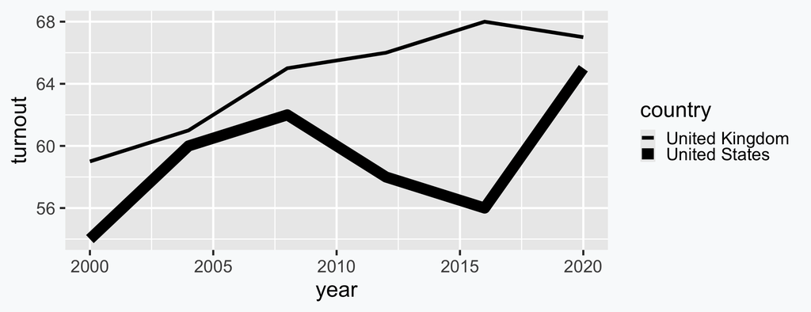

```r
ggplot(eg5, aes(x = year, y = turnout, linewidth = country)) +
  geom_line()
```

## geom_line

### linetype(discrete)

Suppose we have data on average voter turnout (%) in national elections over several years for the US and the UK. We want to see the trend in participation.

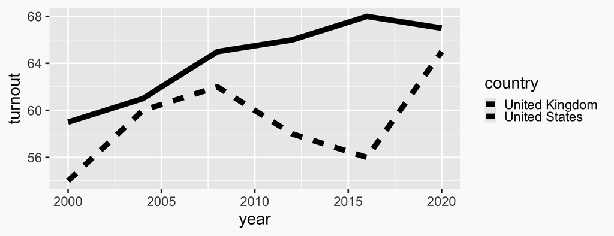

```r
ggplot(eg5, aes(x = year, y = turnout, linetype = country)) +
  geom_line()
```

## geom_line

### Line Types and Color

Suppose we have data on average voter turnout (%) in national elections over several years for the US and the UK. We want to see the trend in participation.

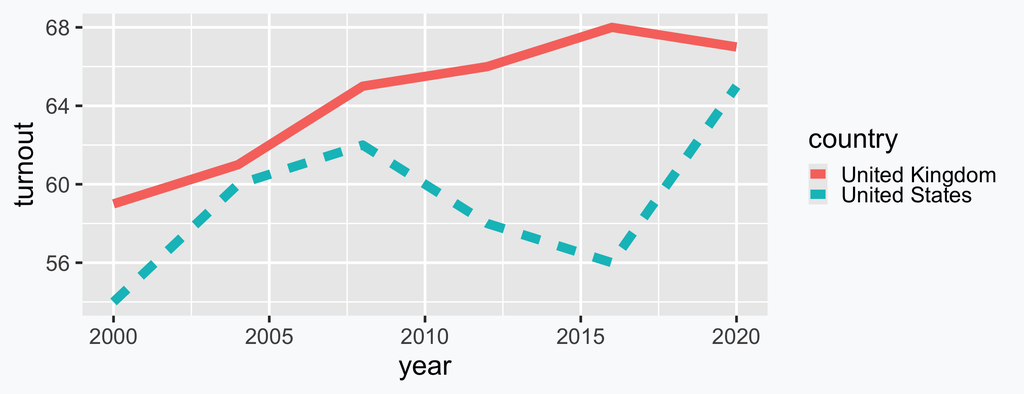

```r
ggplot(eg5, aes(x = year, y = turnout,
      linetype = country, color = country)) +
  geom_line()
```

## geom_line

### Line Types, Color, and Points

Suppose we have data on average voter turnout (%) in national elections over several years for the US and the UK. We want to see the trend in participation.

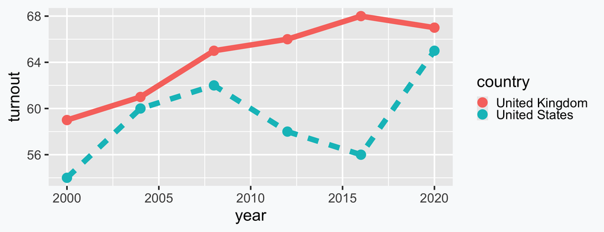

```r
ggplot(eg5, aes(x = year, y = turnout,
  linetype = country, color = country)) +
  geom_line() +
  geom_point()
```

# Complex Geom Aesthetics

## Complex Geom Aesthetics

| Geom | Useful aesthetics | Avoid |
| --- | --- | --- |
| Boxplot | fill, color | size, shape |
| Histogram | fill, alpha | shape |
| Density | color, linetype | size |
| Violin | fill, color | shape |
| Smooth | color, linetype | size |
| SF (maps) | fill, color | shape |

## Complex Geoms

### `geom_boxplot`

Suppose we surveyed people about their trust in government on a 1–10 scale (1 = no trust, 10 = complete trust). We want to compare typical values and how spread out the answers are for men and women.

```r
set.seed(123)

# Toy survey dataset
eg6 <- data.frame(
  gender = rep(c("Men", "Women"), each = 20),
  trust = c(
    rnorm(20, mean = 5, sd = 2),
    rnorm(20, mean = 8, sd = 1)
  )
)
```

## Complex Geoms

### `geom_boxplot`

Suppose we surveyed people about their trust in government on a 1–10 scale (1 = no trust, 10 = complete trust). We want to compare typical values and how spread out the answers are for men and women.

| gender | trust |
| --- | --- |
| Men | 3.879049 |
| Men | 4.539645 |
| Men | 8.117417 |
| Men | 5.141017 |
| Men | 5.258576 |
| Men | 8.430130 |
| Men | 5.921832 |
| Men | 2.469877 |

## Complex Geoms

### `geom_boxplot`

Suppose we surveyed people about their trust in government on a 1–10 scale (1 = no trust, 10 = complete trust). We want to compare typical values and how spread out the answers are for men and women.

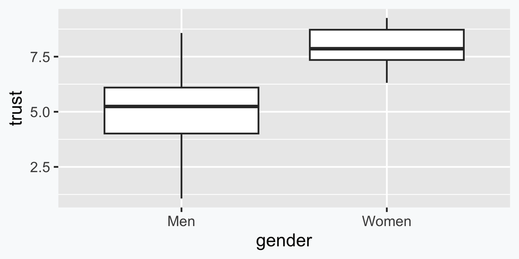

```r
ggplot(eg6, aes(x = gender, y = trust)) +
  geom_boxplot()
```

## Complex Geoms

### `geom_boxplot`: fill(color)

Suppose we surveyed people about their trust in government on a 1–10 scale (1 = no trust, 10 = complete trust). We want to compare typical values and how spread out the answers are for men and women.

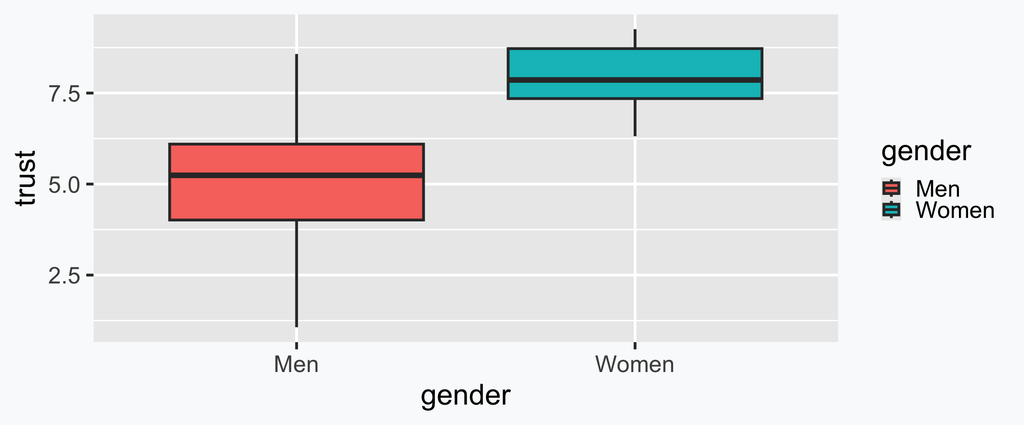

```r
ggplot(eg6, aes(x = gender, y = trust, fill = gender)) +
  geom_boxplot()
```

## Complex Geoms

### `geom_histogram`: fill + alpha

Suppose we surveyed people about their trust in government on a 1–10 scale (1 = no trust, 10 = complete trust). We want to compare typical values and how spread out the answers are for men and women.

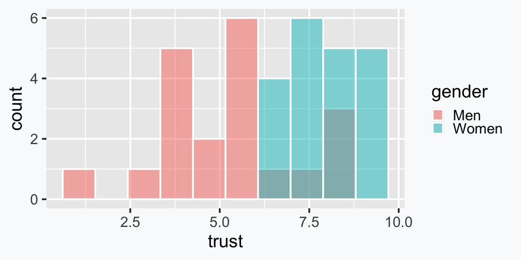

```r
ggplot(eg6, aes(x = trust, fill = gender)) +
  geom_histogram(bins = 10, color = "white", alpha = 0.5, position = "identity")
```

## Complex Geoms

### `geom_sf` fill(color)

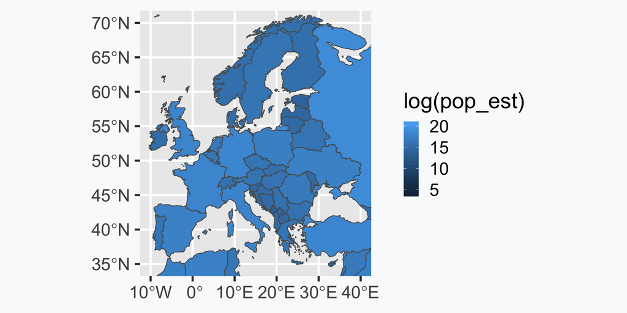

```r
library(ggplot2)
library(sf)
library(rnaturalearth)
library(rnaturalearthdata)

world <- ne_countries(scale = "medium",
                      returnclass = "sf")
europe_bounds <- list(x = c(-10, 40),
                      y = c(35, 70))

# Mapping it
ggplot() +
  geom_sf(data = world, aes(fill=log(pop_est))) +
  coord_sf(xlim = europe_bounds$x,
           ylim = europe_bounds$y)
```

# Color and Accessibility

## Colors

On the most fundamental level, we need to use the right colors for our visualizations

This is relevant for:

- **Clarity and Readability**: users can distinguish among different categories
- **Accessibility**: color-blind people can also see the different categories in your visualization
- **Emphasis**: the right colors can be used to emphasize specific aspects of the data or analysis
- **Consistency**: using a consistent color palette for the same project is helpful

## Color Statistics

8% of men and 0.5% of women have some form of color blindness

Thus, colors should be distinguishable by people with different forms of color blindness

## Color Contrasts

The Viridis palette in R allows us to create color-blind-friendly graphs

These are predefined palettes that are widely used.

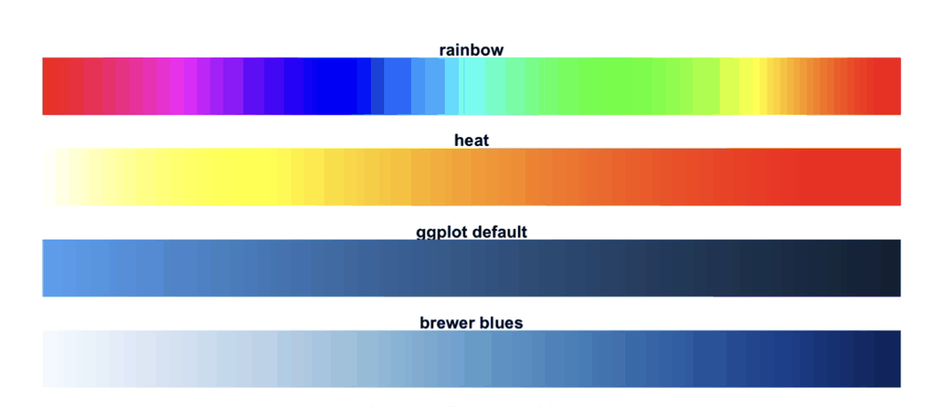

Color-blind Not Friendly

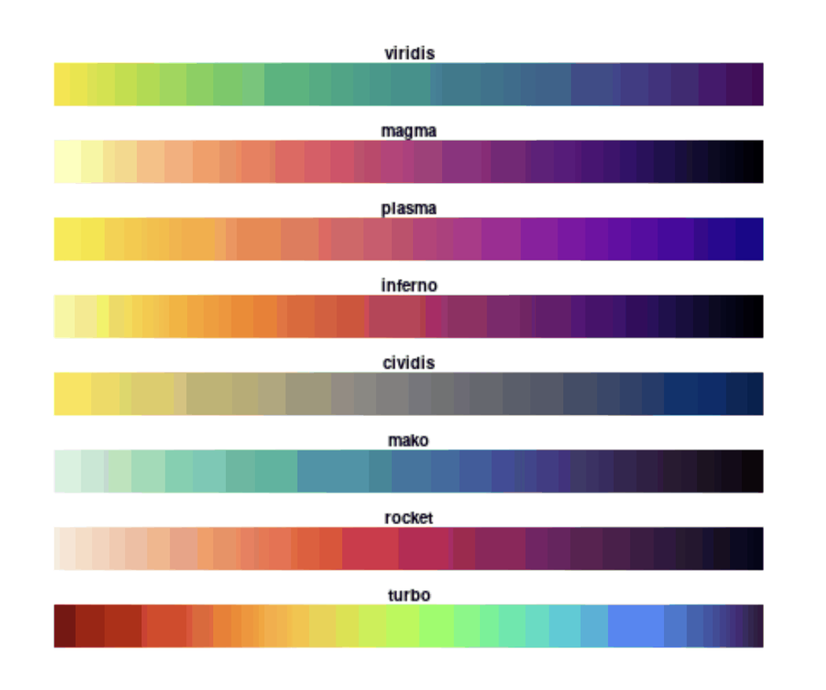

Color-blind Friendly

## geom_point

### color(discrete) - No Viridis

Imagine we have data about 9 countries that record their level of democracy from -10 to +10 (x-axis) and their GDP per capita in $1,000s (y-axis).

Let’s imagine that we have a new dataset with more variables:

```r
# Reusable dataset
eg1 <- data.frame(
  country = c(
    "North Korea",   # very autocratic, very poor
    "Saudi Arabia",  # autocratic, but richer due to oil
    "Zimbabwe",      # authoritarian, low GDP
    "Russia",        # hybrid regime, middle income
    "Nigeria",       # similar position
    "India",         # low–mid democracy, growing GDP
    "Brazil",        # democracy, mid GDP
    "Poland",        # consolidated democracy, higher GDP
    "South Korea"   # rich democracy
  ),
  democracy = c(-8, -7, -5, -3, 0, 2, 5, 8, 9),          # democracy score
  gdp = c(2, 9, 4, 7, 8, 20, 15, 25, 27),          # GDP per capita ($1,000s)
  region = c("Asia", "Asia", "Africa",
             "Europe", "Africa", "Asia",
             "Americas", "Europe", "Asia"),        # categorical
  population = c(5, 50, 30, 12, 80, 60, 40, 100, 70), # continuous (millions)
  income_group = factor(
    c("Low", "Low", "Low",
      "Middle", "Middle", "Middle",
      "High", "High", "High"),
    levels = c("Low", "Middle", "High")),
  corruption = c(80, 65, 50, 40, 35, 30, 25, 20, 15))
```

## geom_point

### color(discrete) - No Viridis

Imagine we have data about 9 countries that record their level of democracy from -10 to +10 (x-axis) and their GDP per capita in $1,000s (y-axis).

Let’s imagine that we have a new dataset with more variables:

| country | democracy | gdp | region | population | income_group | corruption |
| --- | --- | --- | --- | --- | --- | --- |
| North Korea | -8 | 2 | Asia | 5 | Low | 80 |
| Saudi Arabia | -7 | 9 | Asia | 50 | Low | 65 |
| Zimbabwe | -5 | 4 | Africa | 30 | Low | 50 |
| Russia | -3 | 7 | Europe | 12 | Middle | 40 |
| Nigeria | 0 | 8 | Africa | 80 | Middle | 35 |

## geom_point

### color(discrete) - No Viridis

Imagine we have data about 9 countries that record their level of democracy from -10 to +10 (x-axis) and their GDP per capita in $1,000s (y-axis).

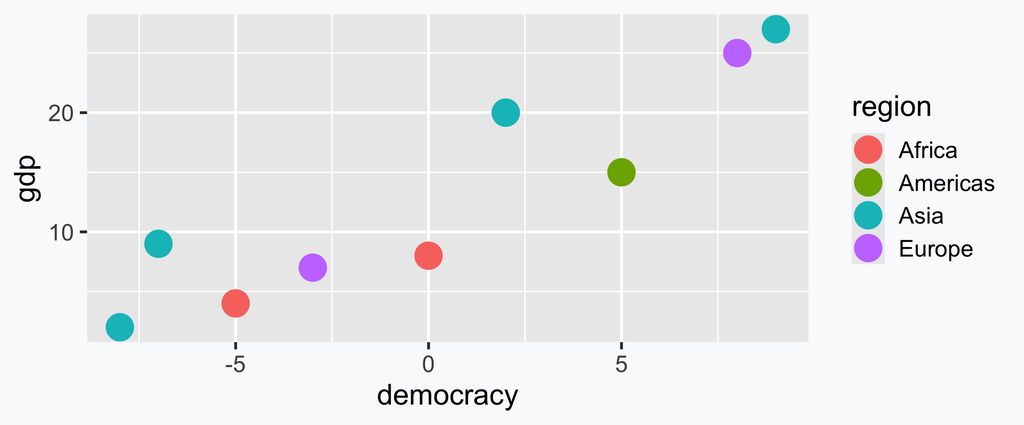

```r
# 1) color (discrete): differentiate categories with distinct hues
ggplot(eg1, aes(x = democracy, y = gdp, color = region)) +
  geom_point()
```

## geom_point

### color(discrete) - Viridis

Imagine we have data about 9 countries that record their level of democracy from -10 to +10 (x-axis) and their GDP per capita in $1,000s (y-axis).

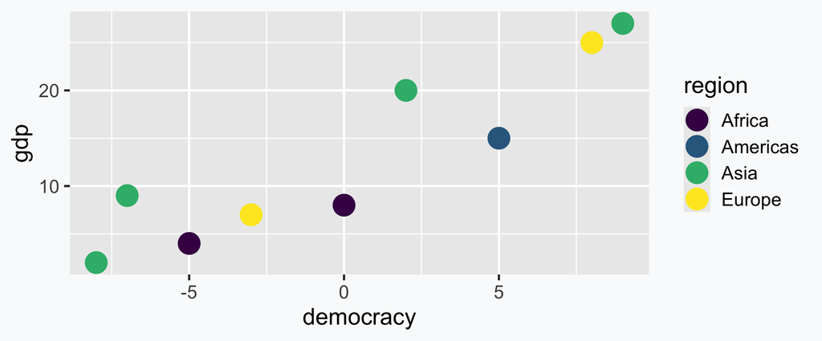

```r
# 1) color (discrete): differentiate categories with distinct hues
ggplot(eg1, aes(x = democracy, y = gdp, color = region)) +
  geom_point()+
  scale_color_viridis_d(option = "viridis")  # you can also try "magma", "inferno", "cividis", etc.
```

## geom_point

### color(continuous) - No Viridis

Imagine we have data about 9 countries that record their level of democracy from -10 to +10 (x-axis) and their GDP per capita in $1,000s (y-axis).

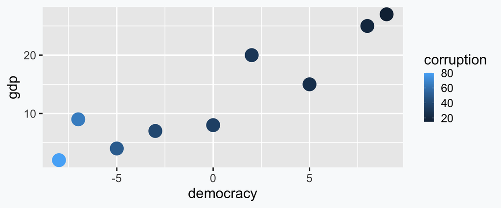

```r
# 2) color (continuous): encode a numeric gradient (low → high)
ggplot(eg1, aes(x = democracy, y = gdp, color = corruption)) +
  geom_point()
```

## geom_point

### color(continuous) - Viridis

Imagine we have data about 9 countries that record their level of democracy from -10 to +10 (x-axis) and their GDP per capita in $1,000s (y-axis).

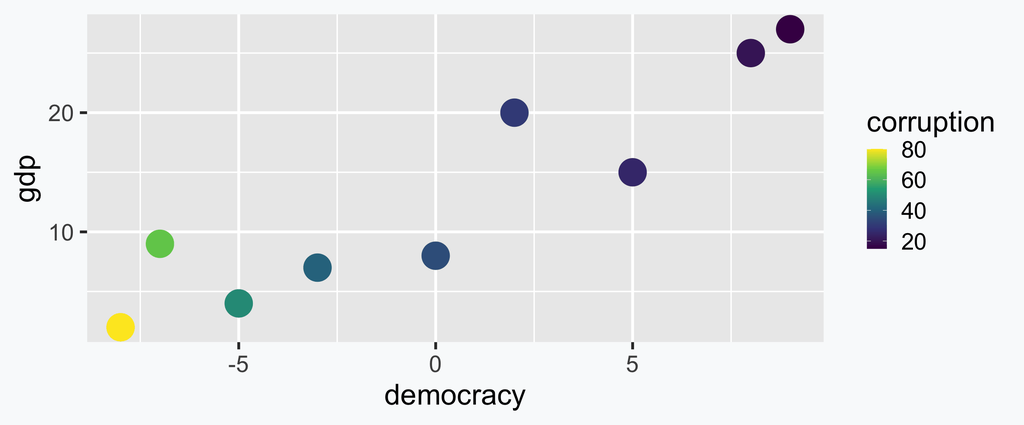

```r
# 2) color (continuous): encode a numeric gradient (low → high)
ggplot(eg1, aes(x = democracy, y = gdp, color = corruption)) +
  geom_point()+
  scale_color_viridis_c(option = "viridis")  # you can also try "magma", "inferno", "cividis", etc.
```

## Complex Geoms

### `geom_sf` fill(color) - No Viridis

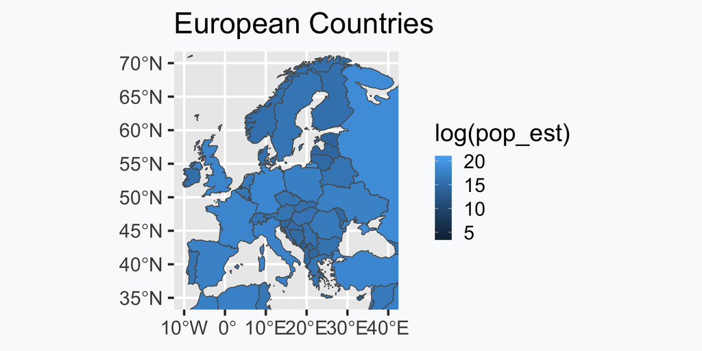

```r
library(ggplot2)
library(sf)
library(rnaturalearth)
library(rnaturalearthdata)

world <- ne_countries(scale = "medium",
                      returnclass = "sf")
europe_bounds <- list(x = c(-10, 40),
                      y = c(35, 70))

# Mapping it
ggplot() +
  geom_sf(data = world, aes(fill=log(pop_est))) +
  coord_sf(xlim = europe_bounds$x,
           ylim = europe_bounds$y) +
  labs(title = "European Countries")
```

## Complex Geoms

### `geom_sf` fill(color) - Viridis

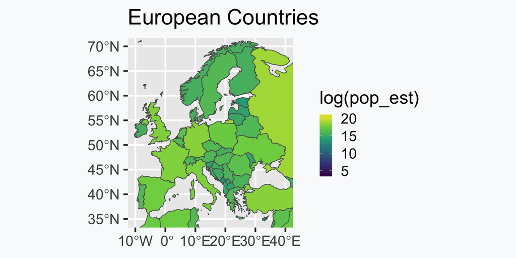

```r
library(ggplot2)
library(sf)
library(rnaturalearth)
library(rnaturalearthdata)

world <- ne_countries(scale = "medium",
                      returnclass = "sf")
europe_bounds <- list(x = c(-10, 40),
                      y = c(35, 70))

# Mapping it
ggplot() +
  geom_sf(data = world, aes(fill=log(pop_est))) +
  coord_sf(xlim = europe_bounds$x,
           ylim = europe_bounds$y) +
  labs(title = "European Countries")+
  scale_fill_viridis_c(option = "viridis")  # you can also try "magma", "inferno", "cividis", etc.
```

# Conclusion

## Conclusion

- Geoms provide the structure; aesthetics add meaning
- Use aesthetics (color, size, shape, alpha, linetype) to highlight patterns
- Remember: mapping = variable-driven | setting = fixed value
- Aesthetics can clarify or confuse — use them thoughtfully
- Goal: craft plots that are clear, engaging, and persuasive

# Exercises

## geom_point

### color(continuous)

What do you see?

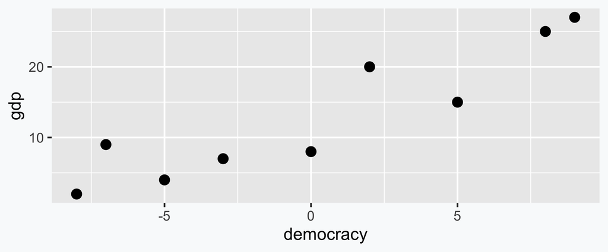

```r
ggplot(eg1, aes(x = democracy, y = gdp)) +
  geom_point()
```

## geom_point

### color(continuous)

How does the story change?

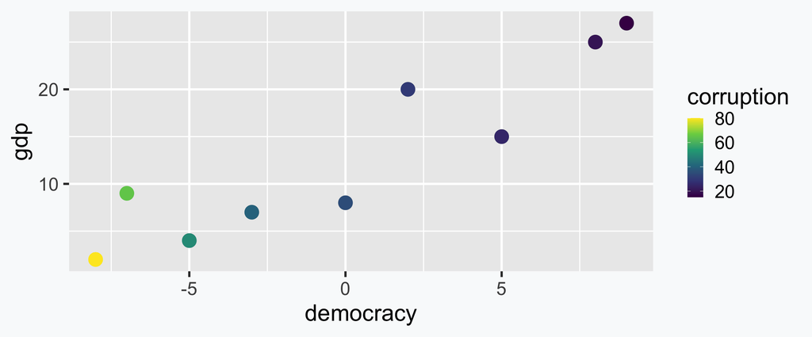

```r
# 2) color (continuous): encode a numeric gradient (low → high)
ggplot(eg1, aes(x = democracy, y = gdp, color=corruption)) +
  geom_point() +
  scale_color_viridis_c(option = "viridis")  # you can also try "magma", "inferno", "cividis", etc.
```

## geom_point

### size(continuous)

What does adding size tell us?

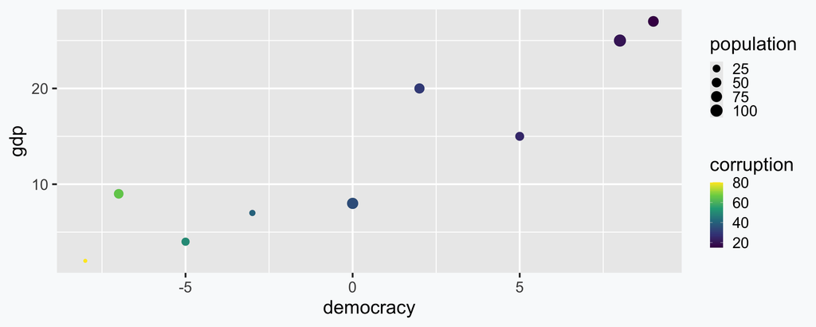

```r
# color (continuous): encode a numeric gradient (low → high)
# size (continuous): encode magnitude with point size
ggplot(eg1, aes(x = democracy, y = gdp, color=corruption, size=population)) +
  geom_point() +
  scale_color_viridis_c(option = "viridis")  # you can also try "magma", "inferno", "cividis", etc.
```

# Exercises Answers

## geom_point

### color(discrete)

What do you see?

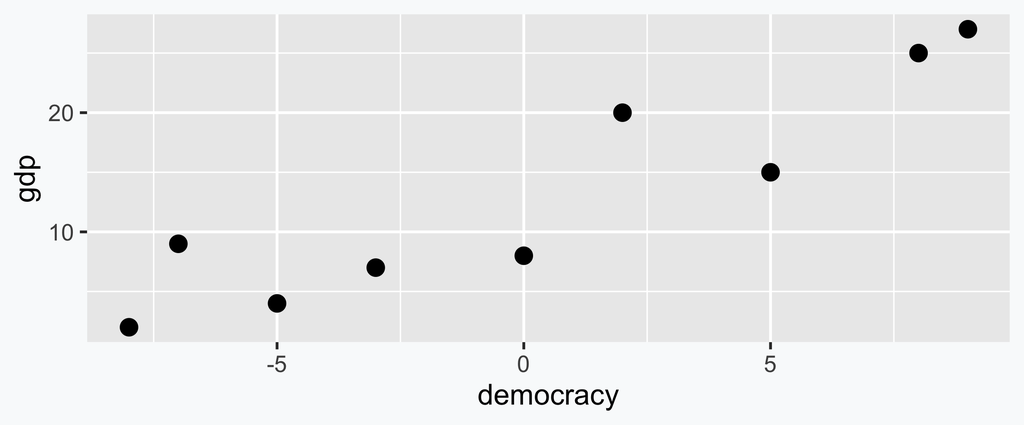

```r
ggplot(eg1, aes(x = democracy, y = gdp)) +
  geom_point()
```

democracy ↔︎ gdp

## geom_point

### color(continuous)

How does the story change?

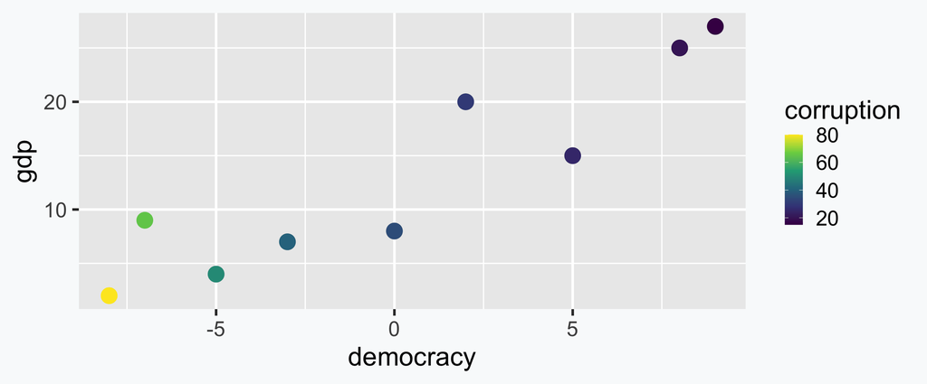

```r
# 2) color (continuous): encode a numeric gradient (low → high)
ggplot(eg1, aes(x = democracy, y = gdp, color=corruption)) +
  geom_point() +
  scale_color_viridis_c(option = "viridis")  # you can also try "magma", "inferno", "cividis", etc.
```

Corruption and Institutions matter

## geom_point

### color(continuous)

What does adding size tell us?

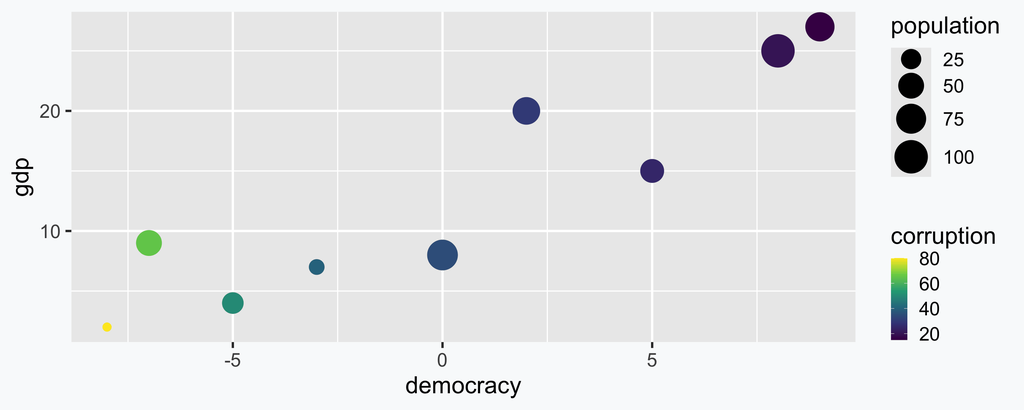

```r
# color (continuous): encode a numeric gradient (low → high)
# size (continuous): encode magnitude with point size
ggplot(eg1, aes(x = democracy, y = gdp, color=corruption, size=population)) +
  geom_point() +
  scale_color_viridis_c(option = "viridis")  # you can also try "magma", "inferno", "cividis", etc.
```